# Basic Linear Regression

## Basic Linear Regression

In this assignment, I have tried to build a basic linear regression model. I have taken the [Auto MPG Data Set](http://archive.ics.uci.edu/ml/datasets/Auto+MPG) from UCI Machine Learning Repository. The response variable is **mpg** (miles per gallon) and explanatory variable is **weight** of the car. Both the variable are numeric in nature.

## Loading Libraries

```python
import pandas as pd
import numpy as np
import seaborn as sns
import matplotlib.pyplot as plt
import statsmodels.api
import statsmodels.formula.api as smf
```

## Loading Data Set

```python
data = pd.read_csv("auto-mpg.data",
                   delim_whitespace=True,
                   header=None,
                   usecols=[0, 4],
                   names=['mpg', 'weight'])
```

## Summarizing Data Set

```python
data.describe()
```

|  | mpg | weight |
| --- | --- | --- |
| count | 398.000000 | 398.000000 |
| mean | 23.514573 | 2970.424623 |
| std | 7.815984 | 846.841774 |
| min | 9.000000 | 1613.000000 |
| 25% | 17.500000 | 2223.750000 |
| 50% | 23.000000 | 2803.500000 |
| 75% | 29.000000 | 3608.000000 |
| max | 46.600000 | 5140.000000 |

## Centering Explanatory Variable

As we can see from above summary, our explanatory variable **weight** does not have 0 in its range. So we need to do **centering** for the variable to get some meaningful results.

```python
mean = round(data['weight'].mean(), 2)
data['weight'] = data['weight'] - mean
data.describe()
```

|  | mpg | weight |
| --- | --- | --- |
| count | 398.000000 | 398.000000 |
| mean | 23.514573 | 0.004623 |
| std | 7.815984 | 846.841774 |
| min | 9.000000 | -1357.420000 |
| 25% | 17.500000 | -746.670000 |
| 50% | 23.000000 | -166.920000 |
| 75% | 29.000000 | 637.580000 |
| max | 46.600000 | 2169.580000 |

## Linear Regression

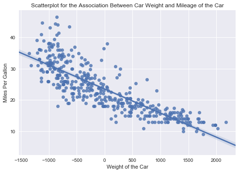

```python
scat1 = sns.regplot(x="weight", y="mpg", scatter=True, data=data)
plt.xlabel('Weight of the Car')
plt.ylabel('Miles Per Gallon')
plt.title ('Scatterplot for the Association Between Car Weight and Mileage of the Car')
plt.show()
```

```python
print ("OLS regression model for the association between car weight and mileage of the car")
reg1 = smf.ols('mpg ~ weight', data=data).fit()
print (reg1.summary())
```

```
OLS regression model for the association between car weight and mileage of the car
                            OLS Regression Results
==============================================================================
Dep. Variable:                    mpg   R-squared:                       0.692
Model:                            OLS   Adj. R-squared:                  0.691
Method:                 Least Squares   F-statistic:                     888.9
Date:                Tue, 26 Sep 2017   Prob (F-statistic):          2.97e-103
Time:                        00:37:20   Log-Likelihood:                -1148.4
No. Observations:                 398   AIC:                             2301.
Df Residuals:                     396   BIC:                             2309.
Df Model:                           1
Covariance Type:            nonrobust
==============================================================================
                 coef    std err          t      P>|t|      [0.025      0.975]
------------------------------------------------------------------------------
Intercept     23.5146      0.218    107.976      0.000      23.086      23.943
weight        -0.0077      0.000    -29.814      0.000      -0.008      -0.007
==============================================================================
Omnibus:                       40.423   Durbin-Watson:                   0.797
Prob(Omnibus):                  0.000   Jarque-Bera (JB):               56.695
Skew:                           0.713   Prob(JB):                     4.89e-13
Kurtosis:                       4.176   Cond. No.                         846.
==============================================================================

Warnings:
[1] Standard Errors assume that the covariance matrix of the errors is correctly specified.
```

From the above simple linear regression model, we can make the following conclusions

1. We got **p-value = 2.97e-103** which is very very less. So we can say that our basic linear regression model is significant.
2. The **R-squared = 0.692**, which means that 69.2% of the variable in the response variable **mpg** is explained by the explanatory variable **weight**
3. The Regression Equation is given by  
   **=> mpg = intercept - 0.0077 * weight**  
   **=> mpg = 23.5146 - 0.0077 * weight**